# ds202_lab4_team

Rithwik Gokhale and Tyren teav

3/19/2021

```r
library(readxl)
```

```r
defense <- read_excel('C:/Users/rithw/Desktop/School work/DS 202/cyclonesFootball2020.xlsx', sheet='Defensive')

offense <- read_excel('C:/Users/rithw/Desktop/School work/DS 202/cyclonesFootball2020.xlsx', sheet='Offensive')

biography <- read_excel('C:/Users/rithw/Desktop/School work/DS 202/cyclonesFootball2020.xlsx', sheet='Biography')
```

Q1Part1

```r
defClean <- defense %>%
  mutate(Name = as.factor(Name),
         Opponent_Opponent = as.factor(Opponent_Opponent),
         Tackles_Solo = as.numeric(Tackles_Solo),
         Tackles_ASST = as.numeric(Tackles_ASST),
         Tackles_TFL = as.numeric(Tackles_TFL),
         Tackles_Sack = as.numeric(Tackles_Sack),
         Turnover_FF = as.numeric(Turnover_FF),
         Turnover_FR = as.numeric(Turnover_FR),
         Turnover_INT = as.numeric(Turnover_INT),
         Pass_QBH = as.numeric(Pass_QBH),
         Pass_PB = as.numeric(Pass_PB))
str(defClean)
```

```
## tibble [372 x 11] (S3: tbl_df/tbl/data.frame)
##  $ Name             : Factor w/ 37 levels "Akers, Landen",..: 26 26 26 26 26 26 26 26 26 26 ...
##  $ Opponent_Opponent: Factor w/ 11 levels "Baylor","Kansas",..: 4 8 5 10 6 2 1 3 9 11 ...
##  $ Tackles_Solo     : num [1:372] 2 6 6 3 7 4 7 4 4 2 ...
##  $ Tackles_ASST     : num [1:372] 4 4 5 0 3 1 4 3 9 3 ...
##  $ Tackles_TFL      : num [1:372] 1 0 1.5 1 1 0 1.5 2.5 1.5 0 ...
##  $ Tackles_Sack     : num [1:372] 0 0 0.5 0 0 0 0 1 0 0 ...
##  $ Turnover_FF      : num [1:372] 0 0 0 0 0 0 0 0 0 0 ...
##  $ Turnover_FR      : num [1:372] 0 0 0 0 0 0 0 0 0 0 ...
##  $ Turnover_INT     : num [1:372] 0 1 0 0 1 0 1 1 0 0 ...
##  $ Pass_QBH         : num [1:372] 0 0 1 0 0 0 2 1 0 0 ...
##  $ Pass_PB          : num [1:372] 0 0 0 0 0 1 0 0 1 0 ...
```

Q1Part2

```r
offClean <- offense %>%
  mutate(Name = as.factor(Name),
         Opponent_Opponent = as.factor(Opponent_Opponent),
         Rushing_ATT = as.numeric(Rushing_ATT),
         Rushing_YDS = as.numeric(Rushing_YDS),
         Rushing_TD = as.numeric(Rushing_TD),
         Receiving_REC = as.numeric(Receiving_REC),
         Receiving_YDS = as.numeric(Receiving_YDS),
         Receiving_TD = as.numeric(Receiving_TD),
         `Passing_CMP-ATT` = as.numeric(`Passing_CMP-ATT`),
         Passing_YDS = as.numeric(Passing_YDS),
         Passing_TD = as.numeric(Passing_TD),
         Passing_INT = as.numeric(Passing_INT))
str(offClean)
```

```
## tibble [156 x 12] (S3: tbl_df/tbl/data.frame)
##  $ Name             : Factor w/ 16 levels "Akers, Landen",..: 1 1 1 1 1 1 1 1 1 1 ...
##  $ Opponent_Opponent: Factor w/ 11 levels "Baylor","Kansas",..: 4 8 5 10 6 2 1 3 9 11 ...
##  $ Receiving_REC    : num [1:156] 0 2 1 4 0 6 1 0 1 1 ...
##  $ Receiving_YDS    : num [1:156] 0 60 35 34 0 76 11 0 10 2 ...
##  $ Receiving_TD     : num [1:156] 0 0 0 0 0 0 0 0 0 1 ...
##  $ Rushing_ATT      : num [1:156] NA NA NA NA NA NA NA NA NA NA ...
##  $ Rushing_YDS      : num [1:156] NA NA NA NA NA NA NA NA NA NA ...
##  $ Rushing_TD       : num [1:156] NA NA NA NA NA NA NA NA NA NA ...
##  $ Passing_CMP-ATT  : num [1:156] NA NA NA NA NA NA NA NA NA NA ...
##  $ Passing_YDS      : num [1:156] NA NA NA NA NA NA NA NA NA NA ...
##  $ Passing_TD       : num [1:156] NA NA NA NA NA NA NA NA NA NA ...
##  $ Passing_INT      : num [1:156] NA NA NA NA NA NA NA NA NA NA ...
```

Q1Part3

```r
bioClean <- biography %>%
  separate(Height, c('Feet', 'Inches'), '-', convert=TRUE) %>%
  mutate(Name = as.factor(Name),
         Position = as.factor(Position),
         Feet = as.numeric(Feet),
         Inches = as.numeric(Inches),
         Weight = as.numeric(Weight),
         Class = as.factor(Class),
         Hometown = as.factor(Hometown),
         Highschool = as.factor(Highschool))
str(bioClean)
```

```
## tibble [116 x 8] (S3: tbl_df/tbl/data.frame)
##  $ Name      : Factor w/ 116 levels "Akers, Landen",..: 1 2 3 4 5 6 7 8 9 10 ...
##  $ Position  : Factor w/ 14 levels "Deep Snapper",..: 14 13 14 2 9 2 3 3 4 14 ...
##  $ Feet      : num [1:116] 6 6 6 6 6 6 6 6 6 6 ...
##  $ Inches    : num [1:116] 0 7 5 0 0 0 3 2 2 2 ...
##  $ Weight    : num [1:116] 191 240 208 180 195 199 253 261 288 182 ...
##  $ Class     : Factor w/ 8 levels "Freshman","Junior",..: 5 5 3 1 5 5 4 5 5 1 ...
##  $ Hometown  : Factor w/ 96 levels "Adel, Iowa","Alpharetta, Ga.",..: 17 65 82 37 60 40 24 45 45 86 ...
##  $ Highschool: Factor w/ 100 levels "ADM","Ames","Andover",..: 93 65 4 13 16 52 19 78 78 87 ...
```

Q2Part1

```r
offClean2 <- offClean %>%
  pivot_longer(Rushing_ATT:Passing_INT, names_to = 'stat')
str(offClean2)
```

```
## tibble [1,092 x 7] (S3: tbl_df/tbl/data.frame)
##  $ Name             : Factor w/ 16 levels "Akers, Landen",..: 1 1 1 1 1 1 1 1 1 1 ...
##  $ Opponent_Opponent: Factor w/ 11 levels "Baylor","Kansas",..: 4 4 4 4 4 4 4 8 8 8 ...
##  $ Receiving_REC    : num [1:1092] 0 0 0 0 0 0 0 2 2 2 ...
##  $ Receiving_YDS    : num [1:1092] 0 0 0 0 0 0 0 60 60 60 ...
##  $ Receiving_TD     : num [1:1092] 0 0 0 0 0 0 0 0 0 0 ...
##  $ stat             : chr [1:1092] "Rushing_ATT" "Rushing_YDS" "Rushing_TD" "Passing_CMP-ATT" ...
##  $ value            : num [1:1092] NA NA NA NA NA NA NA NA NA NA ...
```

Q2part2

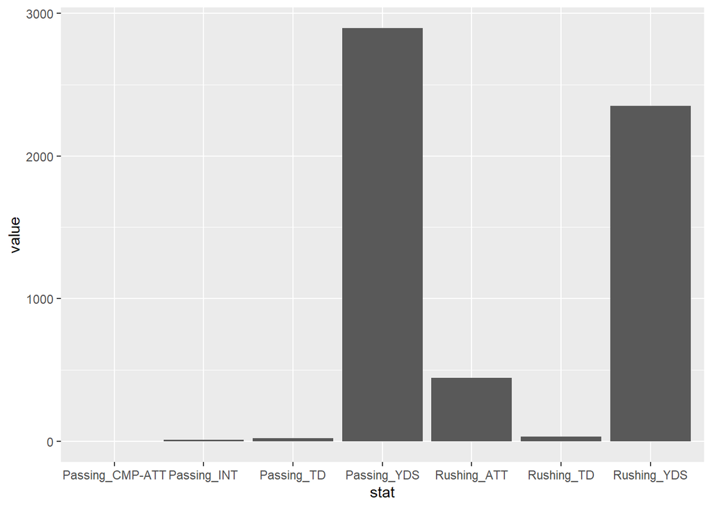

```r
ggplot(offClean2, aes(x = stat, y = value)) + geom_bar(stat = 'identity')
```

This graph shows that the passing and the rushing yars have the highest values compared to any of the other categories

Q2Part3

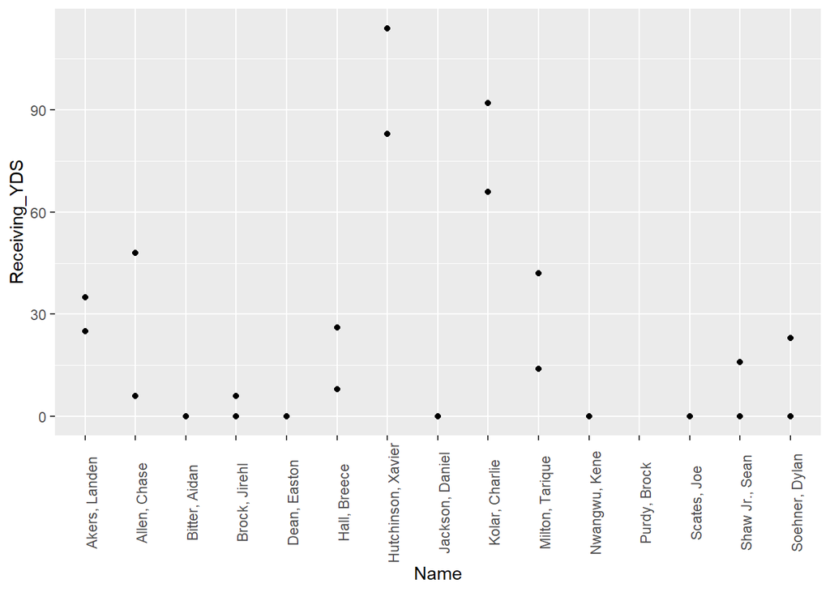

```r
OK <- offClean %>%
  filter(Opponent_Opponent=='Oklahoma') %>%
  ggplot(aes(x=Name, y=Receiving_YDS)) + geom_point() + theme(axis.text.x = element_text(angle=90))
OK
```

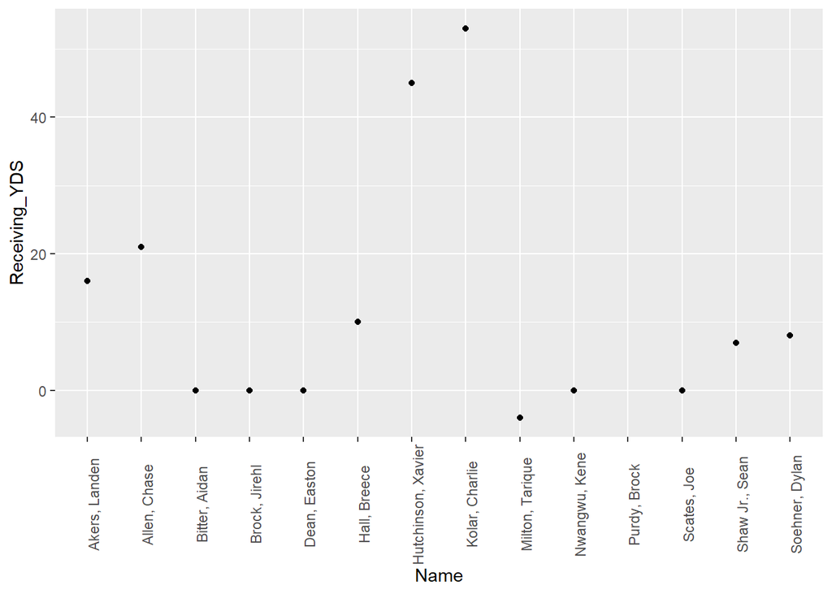

```r
OR <- offClean %>%
  filter(Opponent_Opponent=='Oregon') %>%
  ggplot(aes(x=Name, y=Receiving_YDS)) + geom_point() + theme(axis.text.x = element_text(angle=90))
OR
```

Based on the above displays, I think that Iowa did better against Oklahoma than Oregon when it comes to the offensive plays. I think this is because there are more receiving yards in the Oklahoma game than the Oregon game

Q2Part4 and 5

```r
library(tidyr)
bio2 <- bioClean %>%
  separate(Hometown, c("City","State"), ",")
head(bio2)
```

```
## # A tibble: 6 x 9
##   Name       Position    Feet Inches Weight Class     City     State Highschool
##   <fct>      <fct>      <dbl>  <dbl>  <dbl> <fct>     <chr>    <chr> <fct>
## 1 Akers, La~ Wide Rece~     6      0    191 Redshirt~ Cedar R~ " Io~ Washington
## 2 Allen, Ch~ Tight End      6      7    240 Redshirt~ Nixa     " Mo~ Nixa
## 3 Anderson,~ Wide Rece~     6      5    208 Redshirt~ Seffner  " Fl~ Armwood
## 4 Antoine J~ Defensive~     6      0    180 Freshman  Ft. Lau~ " Fl~ Cardinal G~
## 5 Assalley,~ Placekick~     6      0    195 Redshirt~ Napervi~ " Il~ Central
## 6 Azunna, A~ Defensive~     6      0    199 Redshirt~ Grand P~ " Te~ Lake Ridge
```

```r
state <- bio2 %>%
  group_by(State) %>%
  summarize(
    count = length(State)) %>%
      arrange(count)

state
```

```
## # A tibble: 21 x 2
##    State        count
##    <chr>        <int>
##  1 " Ark."          1
##  2 " Australia"     1
##  3 " Mich"          1
##  4 " Miss."         1
##  5 " Neb."          1
##  6 " Pa."           1
##  7 " Calif."        2
##  8 " Mich."         2
##  9 " Okla."         2
## 10 " S.D."          2
## # ... with 11 more rows
```

Q3Part1

```r
library(ggplot2)
offhome <- left_join(offClean,bio2)
offhome2 <-   offhome[!duplicated(offhome$Name), ]
offhome2 %>%
  group_by(Name) %>%
  summarize(City, State)
```

```
## # A tibble: 16 x 3
##    Name               City          State
##    <fct>              <chr>         <chr>
##  1 Akers, Landen      Cedar Rapids  " Iowa"
##  2 Allen, Chase       Nixa          " Mo."
##  3 Bitter, Aidan      Tampa         " Fla."
##  4 Brock, Jirehl      Quincy        " Ill."
##  5 Dean, Easton       Oswego        " Kan."
##  6 Dekkers, Hunter    Hawarden      " Iowa"
##  7 Hall, Breece       Wichita       " Kan."
##  8 Hutchinson, Xavier Jacksonville  " Fla."
##  9 Jackson, Daniel    Cibolo        " Texas"
## 10 Kolar, Charlie     Norman        " Okla."
## 11 Milton, Tarique    Bradenton     " Fla."
## 12 Nwangwu, Kene      Frisco        " Texas"
## 13 Purdy, Brock       Gilbert       " Ariz."
## 14 Scates, Joe        Dayton        " Ohio"
## 15 Shaw Jr., Sean     Jones         " Okla."
## 16 Soehner, Dylan     Prairie Grove " Ark."
```

```r
defhome <- left_join(defClean,bio2)
defhome2 <-   defhome[!duplicated(defhome$Name), ]
defhome2 %>%
   group_by(Name) %>%
  summarize(City, State)
```

```
## # A tibble: 37 x 3
##    Name              City          State
##    <fct>             <chr>         <chr>
##  1 Akers, Landen     Cedar Rapids  " Iowa"
##  2 Azunna, Arnold    Grand Prairie " Texas"
##  3 Bailey, JaQuan    Jacksonville  " Fla."
##  4 Bailey, Joshua    Jacksonville  " Fla."
##  5 Bankston, Latrell <NA>           <NA>
##  6 Brock, Jirehl     Quincy        " Ill."
##  7 Chambers, Mason   Schertz       " Texas"
##  8 Davis, Dae'Shawn  Cleveland     " Ohio"
##  9 Hathcock, Koby    Mesa          " Ariz."
## 10 Horne, Aric       Jacksonville  " Fla."
## # ... with 27 more rows
```